# Are we more civilized today?

Alexander Hilmer

created 4 October 2021, updated 19 March 2026

# Explore Homicide rates in NW Europe

This exercise is based on the dataset provided by [OurWorldInData project](https://ourworldindata.org/homicides) based at the Oxford University.

## The long-term trend in Homicides in Western Europe

Understanding how homicide rates have changed prior to the modern era requires the help of historians and archivists. Manuel Eisner, a criminology professor at the University of Cambridge, and his colleagues published the Historical Violence Database a compilation of data on long-term trends in homicide rates, in addition to qualitative information such as the cause of death, perpetrator and victim. This database is limited to countries with relatively complete historical records on violence and crime – mainly Western Europe and the US.

Starting in the second half of the nineteenth century, these European regions have consistent police records of those accused of murder or manslaughter and annual counts of homicide victims. To go back further in time, reaching as far back as the thirteenth century, Eisner collected estimates (from historical records of coroner reports, court trials, and the police) of homicide rates made in over ninety publications by scholars.

Homicide rates – measured as the number of homicides per 100,000 individuals – up to 1990 are sourced from Eisner’s (2003) publication and the Historical Violence Database.

Are homicide rates in Europe today lower or higher than in the past? Using the provided dataset, display and describe the long-run homicide rates for the five European regions: Italy, England, Germany, Netherlands and Scandinavia.

```r
library(tidyverse)
library(ggplot2)
```

## Load the available data from ourworldindata.org

The data is downloaded from: https://ourworldindata.org/homicides, or more specifically, from the “data” tab of this graphic: https://ourworldindata.org/grapher/homicide-rates-across-western-europe?time=1300..2016

```r
Western_Europe <- read_csv("data/homicide-rates-across-western-europe.csv")
```

## Inspect the data

```r
head(Western_Europe)
```

```
## # A tibble: 6 × 4
##   Entity  Code   Year Homicide rate in Europe over long-term (per 100,000) (ho…¹
##   <chr>   <chr> <dbl>                                                      <dbl>
## 1 England <NA>   1300                                                         23
## 2 England <NA>   1550                                                          7
## 3 England <NA>   1625                                                          6
## 4 England <NA>   1675                                                          4
## 5 England <NA>   1725                                                          2
## 6 England <NA>   1775                                                          1
## # ℹ abbreviated name:
## #   ¹`Homicide rate in Europe over long-term (per 100,000) (homicides per 100,000 people)`
```

Ok, the data look good except for the column `Homicide rate in Europe over long-term (per 100,000)` which is not very easy to work with.

I Use the `names()` function and assignment key to relabel this column to `homicides_per_100k`

```r
# names() function produces the names of columns as a character vector with 4 elements
names(Western_Europe)
```

```
## [1] "Entity"
## [2] "Code"
## [3] "Year"
## [4] "Homicide rate in Europe over long-term (per 100,000) (homicides per 100,000 people)"
```

```r
# If we can select the fourth element, we can also rename it / reassign a name to it
names(Western_Europe)[4] <- "homicides_per_100k"
names(Western_Europe)[1] <- "Country"
# check the new name!
names(Western_Europe)
```

```
## [1] "Country"            "Code"               "Year"
## [4] "homicides_per_100k"
```

## Let’s see what the long-term trend is in homicides

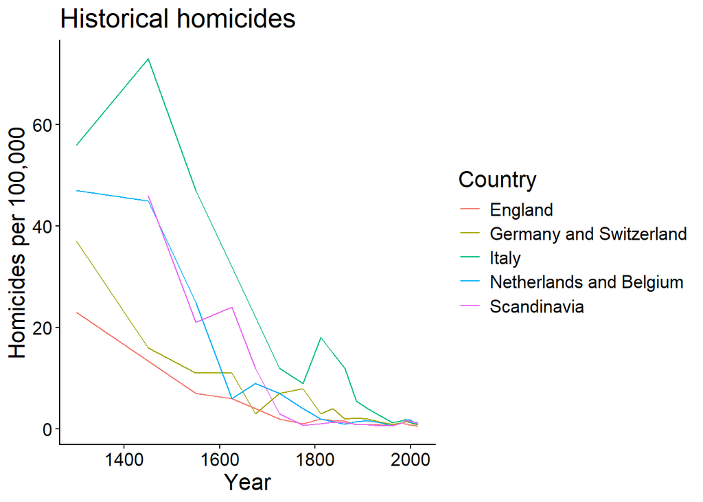

```r
Western_Europe %>%
  ggplot(aes(x=Year,y=homicides_per_100k,color=Country))+
  geom_line()+
  theme_classic()+
  theme(text = element_text(size = 16, family = "sans"))+
   labs(y="Homicides per 100,000", x="Year", title="Historical homicides")
```

## Uncouple the homicides of individual countries for easier view

[figure not shown]

```r
#... YOUR CODE

Western_Europe %>%
  ggplot(aes(x=Year,y=homicides_per_100k,color=Country))+
  geom_line()+
  facet_wrap(~Country, ncol=2, nrow=3)+
  theme_classic()+
  theme(
  legend.position = "bottom",
  legend.box.margin = margin(t = 10, r = 0, b = 10, l = 0),
  plot.margin = margin(t = 20, r = 20, b = 50, l = 20),
  text = element_text(size = 14, family = "sans")
        )+
   labs(y="Homicides per 100,000", x="Year", title="Historical homicides")
```

```r
ggsave("homicides.png", width = 15, height = 8,dpi = 300)
```

## Compare the trends in homicide with the pattern of reign duration among Danish rulers through time.

- Load your Danish king dataset. Hopefully it is tidy and your years and duration of reign are all numeric.
- You need to have a consistent way of plotting the rulers’ reign on the x axis, so I recommend you create a midyear column by calculating the middle of each monarch’s rule (Hint: `midyear` = `endyear` - (`endyear`-`startyear`)/2)
- Start a ggplot plotting midyear on x axis and duration on y axis
- Try `geom_smooth()` for geometry
- Provide meaningful labels and a title
- How would you characterize the trend compared to the homicides above? The trend in the duration of reign among Danish rulers through time seems to be generally increasing, with some fluctuations. Compared to the homicides above which are mostly decreasing over time, the duration of reign seems to be increasing.

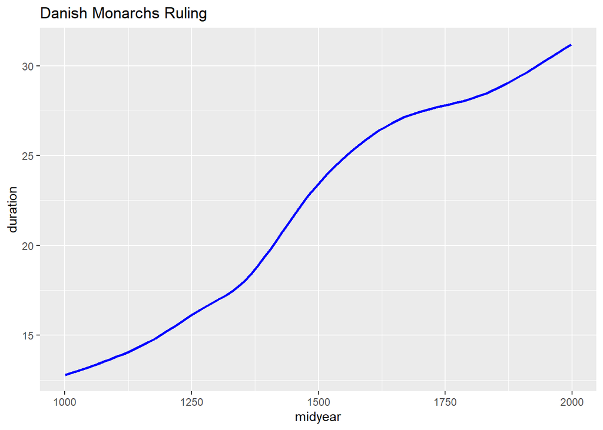

```r
# YOUR CODE HERE:
#Inserting my Data and converting it to numeric to be able to work with it. And creating a midyear column to be able to plot the reign duration on the x axis.
kings <- read_csv("data/kongerækken.csv",na = "NULL")
kings$birth_year  <- as.numeric(kings$birth_year)
kings$death_year  <- as.numeric(kings$death_year)
kings$reign_start <- as.numeric(kings$reign_start)
kings$reign_end   <- as.numeric(kings$reign_end)
midyear <- kings$reign_end - (kings$reign_end - kings$reign_start)/2
kings_duration <- kings %>%
  mutate(duration = reign_end - reign_start)

ggplot(kings_duration, aes(x=midyear, y=duration)) +
  geom_smooth(method = "loess", se = FALSE, color = "blue")+
  labs(title="Danish Monarchs Ruling")
```

```r
#Important is that because some of the data is missing NULL values, the plot is not complete and we cannot see the full trend. But it seems that there is a general increase in the duration of reign over time, with some fluctuations.
```

**Final tasks:**

1. Plot: In the facetted plot above, move the legend from the current position on the side to below the facets, and label it “Country” instead of “Entity”.

As you can see i the code chunk above, I have moved the legend to the bottom and labeled it “Country” instead of “Entity”. Even though its hard to see as the console window is getting clipped which i couldnt fix, the legend is now at the bottom and labeled “Country”.

### Final question:

*In <250 words articulate your answer on the basis of the data visualisations to the following question*: **are we more civilized today?** Its hard to determine whether we are more civilized today based on the data visualizations of homicides and duration of reign among Danish rulers. The trend in homicides seems to be generally decreasing over time, which could suggest that we are becoming more civilized. However, the trend in the duration of reign among Danish rulers seems to be generally increasing, which could suggest that we are not becoming more civilized. But that is also depending on what you would define as being “civilized”.